# Intro to IPython Notebook

[figure not shown]

## What We'll Cover

- IPython Notebook: what is it?
- Problems. We have them.
- Getting up and running
- Next steps/beyond basics

## What We Can't

- Technical Architecture
- Specific installation problems
- Advanced topics in detail

# First Things First

## iPython

[figure not shown]

# IPython Notebook: What is It?

IPython notebook is part of IPython, an interactive computing architecture.

The [IPython Notebook](http://ipython.org/notebook.html) is a web-based interactive computational environment where you can combine code execution, text, mathematics, plots and rich media into a single document.

[figure not shown]

```python
#some Python code
range(0,20)
```

```
[0, 1, 2, 3, 4, 5, 6, 7, 8, 9, 10, 11, 12, 13, 14, 15, 16, 17, 18, 19]
```

Markdown and LaTeX support

[figure not shown]

```python
from IPython.display import YouTubeVideo
# a talk about IPython at Sage Days at U. Washington, Seattle.
# Video credit: William Stein.
YouTubeVideo('QTXyXuqfBLA')
```

[video not shown]

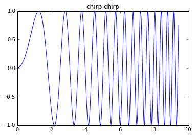

```python
import matplotlib.pyplot as plt
import numpy as np
%matplotlib inline
x = np.linspace(0, 3*np.pi, 500)
plt.plot(x, np.sin(x**2))
plt.title('chirp chirp');
```

# Examples

[Federal Contracts Notebook](http://nbviewer.ipython.org/github/bsweger/nerdsummit/blob/master/FederalContracts.ipynb)  
[Bokeh Visualization Documentation](http://nbviewer.ipython.org/github/ContinuumIO/bokeh-notebooks/blob/master/index.ipynb)  
[Notebook-powered blog](http://www.damian.oquanta.info/)  
[These slides](http://nbviewer.ipython.org/github/bsweger/nerdsummit/blob/master/NERDSPresentation.ipynb)

# How Does it Help?

[figure not shown]

# Show Your Work

[The Ferguson Area is Even More Segregated Than You Probably Guessed](http://www.buzzfeed.com/jsvine/the-ferguson-area-is-even-more-segregated-than-you-thought#2n9wwff), Buzzfeed, 8/20/14

[figure not shown]

[IPython Notebook](https://github.com/BuzzFeedNews/2014-08-st-louis-county-segregation/blob/master/notebooks/segregation-analysis.ipynb)

[NBViewer](http://nbviewer.ipython.org/github/BuzzFeedNews/2014-08-st-louis-county-segregation/blob/master/notebooks/segregation-analysis.ipynb)

# Show Your Work

[Warming Ocean Threatens Sea Life](http://www.scientificamerican.com/article/warming-ocean-threatens-sea-life/), *Scientific American*

[figure not shown]

[IPython notebook](https://github.com/robertodealmeida/notebooks/blob/master/scientific_american/Scientific%20American%20graph.ipynb)

[NBViewer](http://nbviewer.ipython.org/github/robertodealmeida/notebooks/blob/master/scientific_american/Scientific%20American%20graph.ipynb)

# Sharing Without Scaring

[figure not shown]

# Learning

[Teaching with IPython Notebook](http://nbviewer.ipython.org/gist/jiffyclub/5165431)

# Getting Started

## Anaconda Distribution

Linux, Mac, Windows downloads: https://store.continuum.io/cshop/anaconda/

1. Install
2. Open Anaconda Launcher
   - Windows: Start Menu
   - Mac: Launcher.app in ~/anaconda
3. Install IPython Notebook
4. Launch IPython Notebook. This should start up the notebook server and open the notebook dashboard in your browser.

[figure not shown]

# Getting Started

## Existing Python Environment

IPython supports Python 2.7 or 3.3 and newer.

1. Install IPython and it's main optional dependencies (many of these are needed to run the Notebook): pip install ipython[all]
2. If you get an error installing ipython[notebook], install dependencies separately:
   - pip install jinja2
   - pip install sphinx
   - pip install pyzmq
   - pip install pygments
   - pip install tornado
   - pip install ipython
3. [Start](http://ipython.org/ipython-doc/2/notebook/notebook.html#starting-the-notebook-server) the notebook server. This should start up the server and open the notebook dashboard in your browser.
   - ipython notebook
4. Alternately, to start a notebook server from a VM, make sure you're forwarding port 8888 start up the server:
   - ipython notebook --ip=0.0.0.0
   - on the host machine's browser: http://localhost:8888

# What's Happening?

- Dashboard shows notebooks in the current directory
- Each open notebook is connected to a single Python kernal
- Notebooks are a series of cells (code cells, Markdown, etc.)

[figure not shown]

[More information](http://ipython.org/ipython-doc/stable/notebook/notebook.html#introduction)

# Behind the Scenes

- Notebooks are JSON files
- Sharing notebooks
- IPython goodness works
  - [system aliases](http://ipython.org/ipython-doc/dev/interactive/shell.html)
  - tab completion
  - exploring your objects
  - [magics](http://nbviewer.ipython.org/github/ipython/ipython/blob/1.x/examples/notebooks/Cell%20Magics.ipynb)
- Good [overview of interactive IPython goodness](http://ipython.org/ipython-doc/2/interactive/tutorial.html)

# Resources and Digging Deeper

[Running Code in the IPython Notebook](http://nbviewer.ipython.org/github/ipython/ipython/blob/1.x/examples/notebooks/Part%201%20-%20Running%20Code.ipynb)  
[Configuring IPython](http://ipython.org/ipython-doc/dev/config/intro.html)  
[Styling IPython Notebooks](http://nbviewer.ipython.org/github/ketch/teaching-numerics-with-notebooks/blob/master/Styling_notebooks.ipynb)  
Extensions (wait until 3.0)  
[Interactive widgets](http://nbviewer.ipython.org/github/ipython/ipython/blob/2.x/examples/Interactive%20Widgets/Index.ipynb)  
[NBViewer browser extensions](http://jiffyclub.github.io/open-in-nbviewer/)  
[Converting IPython notebook to a Reveal.js-powered slideshow](http://www.damian.oquanta.info/posts/make-your-slides-with-ipython.html)  
[IPython Notebook Security](http://ipython.org/ipython-doc/dev/notebook/security.html)  
[R Markdown](http://rmarkdown.rstudio.com/)

# What's Next

[Roadmap](http://localhost:8888/notebooks/NERDSPresentation.ipynb#) slates IPython 3.0 for fall 2014:

- Continue developing interactive widgets
- Further development of non-Python kernels
- Multi-user notebooks
- [Jupyter](https://speakerdeck.com/fperez/project-jupyter)

# Questions?

Becky Sweger  
bsweger@gmail.com  
@bendystraw